# F1 F0 cue-weighting

# 1. Load necessary materials 📚

## 1.1. Load necessary libraries

```r
library(metR)        # Tools for meteorological data processing
library(readr)       # For reading CSV files efficiently
library(dplyr)       # For data manipulation and transformation
library(tidyr)       # For tidying data (reshaping)
library(ggplot2)     # For creating complex data visualizations
library(lme4)        # For fitting linear mixed-effects models
library(emmeans)     # For computing estimated marginal means (post hoc analysis)
library(lmerTest)    # For hypothesis testing in linear mixed-effects models
library(gridExtra)   # For arranging multiple grid graphics
library(cowplot)     # For creating complex ggplot2 layouts
library(DescTools)   # For descriptive statistics and data exploration
library(sjmisc)      # For data preparation and variable recoding
library(readxl)      # For reading Excel files
library(sjPlot)      # For generating plots and summary tables
library(broom.mixed) # For tidying up model outputs from mixed models
library(scales)      # For scaling and formatting of axes (e.g., percent_format)
library(ggeffects)   # For visualizing effects from regression models
library(ggridges)    # For creating ridge plots
library(patchwork)   # For combining ggplot2 plots
library(smplot2)     # For creating summary plots
library(ggpubr)      # For ggplot2-based publication-ready plots
```

## 1.2. Data Loading

```r
# Read the main data file
df <- read_csv("~/Documents/Research/Code/F1_F0_cue_weighting/Data/data_annotated_v_optim_param_zsco_wth_outliers.csv",show_col_types = FALSE)

# Convert AGE column to factor and specify custom levels
df$AGE <- factor(df$AGE, levels = c("00;06", "00;07", "00;08", "00;09", "00;10", "00;11", "01;00", "01;01", "01;02", "01;03", "01;04", "01;05", "01;06", "01;07", "01;08", "01;09", "01;10", "01;11", "02;00"))


# Read the supplementary data file
cumvoc.y_ALLE_NH <- read_excel("/Users/jeremygenette_studio/Documents/Research/Code/F1_F0_cue_weighting/Data/cumvoc_ALLE_NH_vf.xlsx")

# Process supplementary data
cumvoc.y_ALLE_NH <- cumvoc.y_ALLE_NH %>%
  filter(!is.na(`Cum voc`)) %>%
  select(-`Chronage/HearAge`) %>%
  mutate(item = sub("_.*", "",`OPMERKING: cum op woordvormen, niet op lemma`))

# Merge supplementary data with main data
df <- left_join(df, cumvoc.y_ALLE_NH, by = "item")

# Filter data based on utt_type
df <- df %>%
  filter(utt_type == "LEX")
# Print the first few rows of the merged and filtered data frame

# Convert pho_vwl_nucl column to factor
df$pho_vwl_nucl <- as.factor(df$pho_vwl_nucl)

# Recode the levels for annotation consistency
df$pho_vwl_nucl <- recode_factor(df$pho_vwl_nucl,
                                  "M" = NA_character_, # diphtong
                                  "L" = NA_character_, # diphtong
                                  "K" = NA_character_, # diphtong
                                  "H" = NA_character_, # glottal stop
                                  "2" = "@", # annotation consistency
                                  "<" = "u", # annotation consistency
                                  ")" = "}") # annotation consistency

# Remove NA levels
df$pho_vwl_nucl <- droplevels(df$pho_vwl_nucl)

# Print the first few rows of the merged and filtered data frame
print(head(df))
```

| F0 | F1 | F2 | F3 | F4 | F5 | int | ID_vwl | item | time_code | labels | StartTime | EndTime | CHI [%art] | CHI [%cvs] | CHI [%prb] | CHI [%scv] | CHI [%son] | CHI [%voc] | CHI [main] | nr_vwl_in_sqc | CHI [%pho] | CHI [%cva] | CHI [%syl] | CHI [%cvt] | CHI [%lys] | CHI [%ohp] | CHI [%phw] | utt_type | nr_sgmt_in_sqc | … |
| --- | --- | --- | --- | --- | --- | --- | --- | --- | --- | --- | --- | --- | --- | --- | --- | --- | --- | --- | --- | --- | --- | --- | --- | --- | --- | --- | --- | --- | --- | --- |
| 317 | 1276 | 2305 | 3503 | 4544 | 6654 | 43.488 | ATT010209_30.7789 | ATT010209 | 30.77890 | 30.7789003447312 | 30.571 | 31.708 | NA | NA | NA | NA | NA | NA | bal. | 1 | bA | 1cv./ | 1bA./ | 1cvc/ | 1bAl/ | b'Al | bA | LEX | 2 | … |
| 399 | 1289 | 2336 | 3885 | 6469 | NA | 44.737 | ATT010209_78.111348 | ATT010209 | 78.11135 | 78.1113478324742 | 77.255 | 78.830 | NA | NA | NA | NA | NA | NA | bal. | 1 | bAw | 1cvc/ | 1bAw/ | 1cvc/ | 1bAl/ | b'Al | bAw | LEX | 2 | … |
| 366 | 1105 | 2064 | 4205 | 5360 | NA | 72.498 | ATT010209_87.438287 | ATT010209 | 87.43829 | 87.4382871027566 | 87.000 | 88.306 | NA | NA | NA | NA | NA | NA | bal. | 1 | bAf | 1cvc/ | 1bAf/ | 1cvc/ | 1bAl/ | b'Al | bAf | LEX | 2 | … |
| 314 | 944 | 2006 | 4526 | 5441 | 6649 | 77.751 | ATT010209_88.467386 | ATT010209 | 88.46739 | 88.4673855975037 | 88.306 | 89.590 | NA | NA | NA | NA | NA | NA | bal. | 1 | ba | 1cv./ | 1ba./ | 1cvc/ | 1bAl/ | b'Al | ba | LEX | 2 | … |
| 361 | 1136 | 2076 | 4303 | 5488 | 5973 | 39.968 | ATT010209_99.014686 | ATT010209 | 99.01469 | 99.0146860036088 | 98.700 | 99.715 | NA | NA | NA | NA | NA | NA | bal. | 1 | bAl | 1cvc/ | 1bAl/ | 1cvc/ | 1bAl/ | b'Al | bAl | LEX | 2 | … |
| 408 | 822 | 2053 | 4415 | 5112 | 6404 | 78.909 | ATT010209_148.671144 | ATT010209 | 148.67114 | 148.671144003707 | 148.216 | 149.601 | NA | NA | NA | NA | NA | NA | bal. | 1 | bAw | 1cvc/ | 1bAw/ | 1cvc/ | 1bAl/ | b'Al | bAw | LEX | 2 | … |

# 2. Data preprocessing ⚙️

## 2.1. Normalization of **F0** based on regression approach from Barreda and Nearey (2018) applied to Lobanov’s (1971) Normalization technique

### 2.1.1. Data preprocessing

“To implement this analysis in R, it is first assumed that the data are available in a data frame object in a “long” format with only one log-formant measurement per row. Further, it is assumed that each row of the data frame has (at least) four columns, labeled: G for the single formant measurement, V indicating vowel, K indicating formant number, and S indicating the speaker […]an additional variable (N) may be created to represent the Nvk terms, using the R command: N ¼ factor[interaction (V,K)].” (p.507)

```r
# Convert from wide to long_F0 format
df_long_F0 <- df %>%  # Create a new data frame by transforming the existing one
  select(item, CHILD, AGE, ID_vwl, pho_vwl_nucl, F0) %>%  # Select specific columns from the original data frame
  gather(key = "Frequency", value = "Value", F0)  # Reshape the data from wide to long_F0 format, combining F0 and F1 columns into key-value pairs

df_long_F0$G <- df_long_F0$Value  # assign Value to 'G'
df_long_F0$S <- as.factor(df_long_F0$item)  # Convert the 'item' (=recording session) column to a factor and assign it to 'S'
df_long_F0$V <- as.factor(df_long_F0$pho_vwl_nucl)  # Convert the 'pho_vwl_nucl' column to a factor and assign it to 'V'
```

### 2.1.2. Regression

Considering the anticipated variability in how different vowel types affect F0 and F1 frequencies across speakers, which was not addressed in Barreda’s study, we find it imperative to incorporate interactions.

```r
M_F0 = lm(data = df_long_F0,
       formula = G ~ 0 + S * V, contrasts = list(V=contr.sum))

saveRDS(M_F0, "~/Documents/Research/Code/F1_F0_cue_weighting/VF/MF0.rds")
```

### 2.1.3. Coefficients extraction

```r
# Extract coefficients for F0 for each speaker
Coefficients_F0 <- summary(MF0)$coefficients %>%
  as.data.frame() %>%                                          # Convert coefficients to data frame
  filter(grepl("^S", rownames(.))) %>%                         # Filter rows with speaker IDs
  rename(Speaker_Estimate_F0 = Estimate, Speaker_Std_Error_F0 = `Std. Error`) %>%  # Rename columns
  mutate(item = sub("^S", "", rownames(.))) %>%                # Extract speaker IDs
  filter(!grepl(":", item))                                    # Exclude rows with ":" in speaker IDs

# Left join Coefficients_F0 with df_long_F0 by the 'item' column
df_long_with_coef_F0 <- left_join(df_long_F0, Coefficients_F0, by = "item")

# Calculate F0 regression Normalized values
df_long_with_coef_F0 <- df_long_with_coef_F0 %>%
  group_by(item) %>%                                           # Group by speaker IDs
  mutate(F0_Regression_Normalized = (Value - Speaker_Estimate_F0) / (Speaker_Std_Error_F0 * sqrt(n())))  # Calculate Normalized values

# Print head of df_long_with_coef_F0
head(df_long_with_coef_F0)
```

| item | CHILD | AGE | ID_vwl | pho_vwl_nucl | Frequency | Value | G | S | V | Speaker_Estimate_F0 | Speaker_Std_Error_F0 | t value | Pr(>\|t\|) | F0_Regression_Normalized |
| --- | --- | --- | --- | --- | --- | --- | --- | --- | --- | --- | --- | --- | --- | --- |
| ATT010209 | ATT | 01;02 | ATT010209_30.7789 | A | F0 | 317 | 317 | ATT010209 | A | 569.5156 | 110.5237 | 5.15288 | 2.585321e-07 | -0.4038849 |
| ATT010209 | ATT | 01;02 | ATT010209_78.111348 | A | F0 | 399 | 399 | ATT010209 | A | 569.5156 | 110.5237 | 5.15288 | 2.585321e-07 | -0.2727304 |
| ATT010209 | ATT | 01;02 | ATT010209_87.438287 | A | F0 | 366 | 366 | ATT010209 | A | 569.5156 | 110.5237 | 5.15288 | 2.585321e-07 | -0.3255121 |
| ATT010209 | ATT | 01;02 | ATT010209_88.467386 | a | F0 | 314 | 314 | ATT010209 | a | 569.5156 | 110.5237 | 5.15288 | 2.585321e-07 | -0.4086833 |
| ATT010209 | ATT | 01;02 | ATT010209_99.014686 | A | F0 | 361 | 361 | ATT010209 | A | 569.5156 | 110.5237 | 5.15288 | 2.585321e-07 | -0.3335093 |
| ATT010209 | ATT | 01;02 | ATT010209_148.671144 | A | F0 | 408 | 408 | ATT010209 | A | 569.5156 | 110.5237 | 5.15288 | 2.585321e-07 | -0.2583354 |

## 2.2. Normalization of **F1** based on regression approach from Barreda and Nearey (2018) applied to Lobanov’s (1971) Normalization technique

### 2.2.1. Data preprocessing

“To implement this analysis in R, it is first assumed that the data are available in a data frame object in a “long” format with only one log-formant measurement per row. Further, it is assumed that each row of the data frame has (at least) four columns, labeled: G for the single formant measurement, V indicating vowel, K indicating formant number, and S indicating the speaker […]an additional variable (N) may be created to represent the Nvk terms, using the R command: N ¼ factor[interaction (V,K)].” (p.507)

```r
# Convert from wide to long_F1 format
df_long_F1 <- df %>%  # Create a new data frame by transforming the existing one
  select(item, CHILD, AGE, ID_vwl, pho_vwl_nucl, F1) %>%  # Select specific columns from the original data frame
  gather(key = "Frequency", value = "Value", F1)  # Reshape the data from wide to long_F1 format, combining F1 and F1 columns into key-value pairs

df_long_F1$G <- df_long_F1$Value  # assign Value to 'G'
df_long_F1$S <- as.factor(df_long_F1$item)  # Convert the 'item' (=recording session) column to a factor and assign it to 'S'
df_long_F1$V <- as.factor(df_long_F1$pho_vwl_nucl)  # Convert the 'pho_vwl_nucl' column to a factor and assign it to 'V'
```

### 2.2.2. Regression

Considering the anticipated variability in how different vowel types affect F0 and F1 frequencies across speakers, which was not addressed in Barreda’s study, we find it imperative to incorporate interactions.

```r
M_F1 = lm(data = df_long_F1,
       formula = G ~ 0 + S * V, contrasts = list(V=contr.sum))

saveRDS(M_F1, "~/Documents/Research/Code/F1_F0_cue_weighting/VF/MF1.rds")
```

### 2.2.3. Coefficients extraction

```r
# Extract coefficients for F1 for each speaker
Coefficients_F1 <- summary(MF1)$coefficients %>%
  as.data.frame() %>%                                          # Convert coefficients to data frame
  filter(grepl("^S", rownames(.))) %>%                         # Filter rows with speaker IDs
  rename(Speaker_Estimate_F1 = Estimate, Speaker_Std_Error_F1 = `Std. Error`) %>%  # Rename columns
  mutate(item = sub("^S", "", rownames(.))) %>%                # Extract speaker IDs
  filter(!grepl(":", item))                                    # Exclude rows with ":" in speaker IDs

# Left join Coefficients_F1 with df_long_F1 by the 'item' column
df_long_with_coef_F1 <- left_join(df_long_F1, Coefficients_F1, by = "item")

# Calculate F1 regression Normalized values
df_long_with_coef_F1 <- df_long_with_coef_F1 %>%
  group_by(item) %>%                                           # Group by speaker IDs
  mutate(F1_Regression_Normalized = (Value - Speaker_Estimate_F1) / (Speaker_Std_Error_F1 * sqrt(n())))  # Calculate Normalized values

# Print head of df_long_with_coef_F1
head(df_long_with_coef_F1)
```

| item | CHILD | AGE | ID_vwl | pho_vwl_nucl | Frequency | Value | G | S | V | Speaker_Estimate_F1 | Speaker_Std_Error_F1 | t value | Pr(>\|t\|) | F1_Regression_Normalized |
| --- | --- | --- | --- | --- | --- | --- | --- | --- | --- | --- | --- | --- | --- | --- |
| ATT010209 | ATT | 01;02 | ATT010209_30.7789 | A | F1 | 1276 | 1276 | ATT010209 | A | 1010.911 | 348.2526 | 2.902809 | 0.003701666 | 0.13456209 |
| ATT010209 | ATT | 01;02 | ATT010209_78.111348 | A | F1 | 1289 | 1289 | ATT010209 | A | 1010.911 | 348.2526 | 2.902809 | 0.003701666 | 0.14116103 |
| ATT010209 | ATT | 01;02 | ATT010209_87.438287 | A | F1 | 1105 | 1105 | ATT010209 | A | 1010.911 | 348.2526 | 2.902809 | 0.003701666 | 0.04776069 |
| ATT010209 | ATT | 01;02 | ATT010209_88.467386 | a | F1 | 944 | 944 | ATT010209 | a | 1010.911 | 348.2526 | 2.902809 | 0.003701666 | -0.03396461 |
| ATT010209 | ATT | 01;02 | ATT010209_99.014686 | A | F1 | 1136 | 1136 | ATT010209 | A | 1010.911 | 348.2526 | 2.902809 | 0.003701666 | 0.06349662 |
| ATT010209 | ATT | 01;02 | ATT010209_148.671144 | A | F1 | 822 | 822 | ATT010209 | A | 1010.911 | 348.2526 | 2.902809 | 0.003701666 | -0.09589310 |

## 2.3 Gather Normalization of F0 and F1

```r
# Left join df_long_with_coef_F0 with df_long_with_coef_F1 by the 'ID_vwl' column
df_with_coef_F0_F1_lex <- left_join(df_long_with_coef_F0, df_long_with_coef_F1, by = "ID_vwl") %>%
  rename(item = item.x)  # Rename the 'item' column

# Define the indices of the columns to keep
cols_to_keep <- c(1, 2, 3, 4, 5, 15, 29, 7, 21)

# Extract the desired columns from the dataframe
df_with_coef_F0_F1_lex <- df_with_coef_F0_F1_lex[, cols_to_keep]

# Remove the suffix ".x" from the column names when needed
colnames(df_with_coef_F0_F1_lex) <- gsub("\\.x$", "", colnames(df_with_coef_F0_F1_lex))

df_with_coef_F0_F1_lex$F0 <- df_with_coef_F0_F1_lex$Value
df_with_coef_F0_F1_lex$F1 <- df_with_coef_F0_F1_lex$Value.y

df_with_coef_F0_F1_lex <- df_with_coef_F0_F1_lex %>%
  select(-c(Value, Value.y))

head(df_with_coef_F0_F1_lex)
```

| item | CHILD | AGE | ID_vwl | pho_vwl_nucl | F0_Regression_Normalized | F1_Regression_Normalized | F0 | F1 |
| --- | --- | --- | --- | --- | --- | --- | --- | --- |
| ATT010209 | ATT | 01;02 | ATT010209_30.7789 | A | -0.4038849 | 0.13456209 | 317 | 1276 |
| ATT010209 | ATT | 01;02 | ATT010209_78.111348 | A | -0.2727304 | 0.14116103 | 399 | 1289 |
| ATT010209 | ATT | 01;02 | ATT010209_87.438287 | A | -0.3255121 | 0.04776069 | 366 | 1105 |
| ATT010209 | ATT | 01;02 | ATT010209_88.467386 | a | -0.4086833 | -0.03396461 | 314 | 944 |
| ATT010209 | ATT | 01;02 | ATT010209_99.014686 | A | -0.3335093 | 0.06349662 | 361 | 1136 |
| ATT010209 | ATT | 01;02 | ATT010209_148.671144 | A | -0.2583354 | -0.09589310 | 408 | 822 |

## 2.4. Selection of relevant items

```r
df_combined<- df_with_coef_F0_F1_lex %>%
  mutate(hgt = case_when(
    pho_vwl_nucl %in% c('u', '<', 'i') ~ 'high',
    pho_vwl_nucl %in% c('A', 'a') ~ 'low',
    TRUE ~ NA_character_  # Handle other cases if needed
  ))  %>%
  filter(is.na(hgt)==F) %>%
  select(ID_vwl, F0_Regression_Normalized, F1_Regression_Normalized, pho_vwl_nucl, hgt, CHILD, item, F0, F1)
```

## 2.5. Preparation df for analysis

```r
# Converting 'hgt' to a factor
df_combined$hgt <- as.factor(df_combined$hgt)

# Categorizing 'frt' based on 'pho_vwl_nucl'
df_combined$frt[df_combined$pho_vwl_nucl %in% c("A", "u", "<")] <- "bck"
df_combined$frt[df_combined$pho_vwl_nucl %in% c("i", "a")] <- "frt"

# Merging supplementary data with main data and filtering based on a condition
df_combined <- left_join(df_combined, cumvoc.y_ALLE_NH, by = "item")
df_combined <- df_combined %>%
  filter(`Cum voc` > 0)

# Calculating the logarithm of 'cumvoc.y'
df_combined$log_cum <- log(df_combined$`Cum voc`)

# Final dataframe for analysis
df <- df_combined %>%
  mutate(hgt = as.factor(hgt),
         CHILD = as.factor(CHILD),
         item = as.factor(item),
         frt = as.factor(frt))

df$hgt <- relevel(df$hgt, ref="low") # set reference level to low for better interpretability

# Apply deviation (sum) contrasts to 'hgt' and 'frt'
# This codes each level relative to the overall mean of the dependent variable
contrasts(df$hgt) <- contr.sum(levels(df$hgt))  # Apply contr.sum to 'hgt'
contrasts(df$frt) <- contr.sum(levels(df$frt))  # Apply contr.sum to 'frt'
```

# 3. Data analysis 🧮

## 3.1. Descriptive Statistics

```r
# Calculate mean and standard deviation of F1 for each pho_vwl_nucl category (Normalized)
df_descr <- df %>%
  group_by(hgt) %>%   # Group by pho_vwl_nucl category
  mutate(F1_F0_Hz = F1-F0,
         F1_F0_Normalized = F1_Regression_Normalized-F0_Regression_Normalized) %>%
  summarise(
    m_F1_Hz = round(mean(F1), 2),             # Mean F1 (Hz)
    sd_F1_Hz = round(sd(F1), 2),               # Standard deviation of F1 (Hz)
    m_F0_Hz = round(mean(F0), 2),                # Mean F0 (Hz)
    sd_F0_Hz = round(sd(F0), 2),                 # Standard deviation of F0 (Hz)
    m_F1_F0_Hz = round(mean(F1_F0_Hz), 2),          # Mean F1-F0 difference (Hz)
    sd_F1_F0_Hz = round(sd(F1_F0_Hz), 2),           # Standard deviation of F1-F0 difference (Hz)
    m_F1_Normalized = round(mean(F1_Regression_Normalized), 2),     # Mean F1 (Normalized)
    sd_F1_Normalized = round(sd(F1_Regression_Normalized), 2),       # Standard deviation of F1 (Normalized)
    m_F0_Normalized = round(mean(F0_Regression_Normalized), 2),       # Mean F0 (Normalized)
    sd_F0_Normalized = round(sd(F0_Regression_Normalized), 2),       # Standard deviation of F0 (Normalized)
    m_F1_F0_Normalized = round(mean(F1_F0_Normalized), 2),           # Mean F1-F0 difference (Normalized)
    sd_F1_F0_Normalized = round(sd(F1_F0_Normalized), 2)) %>%       # Standard deviation of F1-F0 difference (Normalized)
  filter(!is.na(hgt))   # Remove rows where hgt is NA

print(df_descr)
```

| hgt | m_F1_Hz | sd_F1_Hz | m_F0_Hz | sd_F0_Hz | m_F1_F0_Hz | sd_F1_F0_Hz | m_F1_Normalized | sd_F1_Normalized | m_F0_Normalized | sd_F0_Normalized | m_F1_F0_Normalized | sd_F1_F0_Normalized |
| --- | --- | --- | --- | --- | --- | --- | --- | --- | --- | --- | --- | --- |
| low | 1026.71 | 292.11 | 372.38 | 84.25 | 654.33 | 284.11 | 0.23 | 0.24 | 0.04 | 0.21 | 0.19 | 0.28 |
| high | 636.29 | 213.87 | 413.07 | 96.84 | 223.23 | 225.98 | -0.05 | 0.18 | 0.11 | 0.22 | -0.16 | 0.27 |

```r
df_descr_phon <- df %>%
  group_by(pho_vwl_nucl) %>%
  summarise(counts = n())

print(df_descr_phon)
```

| pho_vwl_nucl | counts |
| --- | --- |
| u | 1946 |
| a | 6154 |
| A | 3401 |
| i | 1405 |

## 3.1.2. Graphs experimental data

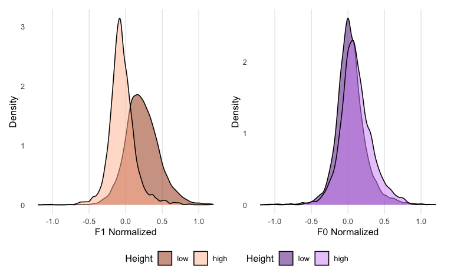

```r
# F1 density plot
p1 <- ggplot(data = df) +
  geom_density(aes(x = F1_Regression_Normalized, fill = hgt), alpha = 0.5) +
  scale_fill_manual(values = c("low" = "#9F3400", "high" = "#FFBE9F"), name = "Height") +
  labs(x = "F1 Normalized", y = "Density") +
  scale_x_continuous(limits = c(-1.2, 1.2)) +
  theme_minimal() +
  theme(
    legend.position = "bottom",
    panel.grid.major.y = element_blank(),
    panel.grid.minor.y = element_blank(),
    panel.grid.minor.x = element_blank()
  )

# F0 density plot
p2 <- ggplot(data = df) +
  geom_density(aes(x = F0_Regression_Normalized, fill = hgt), alpha = 0.5) +
  scale_fill_manual(values = c("low" = "#570987", "high" = "#D397F8"), name = "Height") +
  labs(x = "F0 Normalized", y = "Density") +
  scale_x_continuous(limits = c(-1.2, 1.2)) +
  theme_minimal() +
  theme(
    legend.position = "bottom",
    panel.grid.major.y = element_blank(),
    panel.grid.minor.y = element_blank(),
    panel.grid.minor.x = element_blank()
  )

# Combine with shared legend
(p1 + p2) +
  plot_layout(guides = "collect") &
  theme(legend.position = "bottom")
```

## 3.2. MLM Modelling

### 3.2.1. Model 1: Base model

```r
m1 <- glmer(data= df,
            formula = hgt ~ 1+
              (1|CHILD),  family= "binomial"(link = "logit"),
            control = glmerControl(optimizer = "bobyqa", optCtrl = list(maxfun = 2000000)))
saveRDS(m1, file = "m1.rds")
```

### 3.2.2. Model 2: Fixed effect of cumulative vocabulary

```r
m2 <- glmer(data = df,
            formula = hgt ~ log_cum +
              (1|CHILD),  family = "binomial"(link = "logit"),
            control = glmerControl(optimizer = "bobyqa", optCtrl = list(maxfun = 2000000)))
saveRDS(m2, file = "m2.rds")

as.data.frame(anova(m1,m2))
```

|  | npar | AIC | BIC | logLik | deviance | Chisq | Df | Pr(>Chisq) |
| --- | --- | --- | --- | --- | --- | --- | --- | --- |
| m1 | 2 | 14281.73 | 14296.66 | -7138.865 | 14277.73 | NA | NA | NA |
| m2 | 3 | 14210.86 | 14233.26 | -7102.430 | 14204.86 | 72.87016 | 1 | 1.384658e-17 |

➡️ Better datafit with m2

### 3.2.3. Model 3: Random effect of cumulative vocabulary

```r
m3 <- glmer(data = df,
            formula = hgt ~ log_cum +
              (1 + log_cum | CHILD),  family = "binomial"(link = "logit"),
            control = glmerControl(optimizer = "bobyqa", optCtrl = list(maxfun = 2000000)))
saveRDS(m3, file = "m3.rds")

as.data.frame(anova(m2,m3))
```

|  | npar | AIC | BIC | logLik | deviance | Chisq | Df | Pr(>Chisq) |
| --- | --- | --- | --- | --- | --- | --- | --- | --- |
| m2 | 3 | 14210.86 | 14233.26 | -7102.430 | 14204.86 | NA | NA | NA |
| m3 | 5 | 14147.87 | 14185.20 | -7068.935 | 14137.87 | 66.98975 | 2 | 2.840272e-15 |

➡️ Better datafit with m3

### 3.2.4. Model 4: Fixed effect of F1

```r
m4 <- glmer(data = df,
            formula = hgt ~ log_cum +
              F1_Regression_Normalized+
              (1 + log_cum | CHILD),  family = "binomial"(link = "logit"),
            control = glmerControl(optimizer = "bobyqa", optCtrl = list(maxfun = 2000000)))
saveRDS(m4, file = "m4.rds")

as.data.frame(anova(m3,m4))
```

|  | npar | AIC | BIC | logLik | deviance | Chisq | Df | Pr(>Chisq) |
| --- | --- | --- | --- | --- | --- | --- | --- | --- |
| m3 | 5 | 14147.87 | 14185.20 | -7068.935 | 14137.87 | NA | NA | NA |
| m4 | 6 | 10376.46 | 10421.25 | -5182.228 | 10364.46 | 3773.414 | 1 | 0 |

➡️ Better datafit with m4

### 3.2.5. Model 5: Random slope effect of F1

```r
m5 <- glmer(data = df,
            formula = hgt ~ log_cum +
              F1_Regression_Normalized+
              (1 + log_cum + F1_Regression_Normalized | CHILD),  family = "binomial"(link = "logit"),
            control = glmerControl(optimizer = "bobyqa", optCtrl = list(maxfun = 2000000)))
saveRDS(m5, file = "m5.rds")

as.data.frame(anova(m4,m5))
```

|  | npar | AIC | BIC | logLik | deviance | Chisq | Df | Pr(>Chisq) |
| --- | --- | --- | --- | --- | --- | --- | --- | --- |
| m4 | 6 | 10376.46 | 10421.25 | -5182.228 | 10364.46 | NA | NA | NA |
| m5 | 9 | 10252.98 | 10320.17 | -5117.490 | 10234.98 | 129.4755 | 3 | 7.01617e-28 |

➡️ Better datafit with m5

### 3.2.6. Model 6: Fixed effect of F0

```r
m6 <- glmer(data = df,
            formula = hgt ~ log_cum +
              F1_Regression_Normalized+
              F0_Regression_Normalized+
              (1 + log_cum + F1_Regression_Normalized | CHILD),  family = "binomial"(link = "logit"),
            control = glmerControl(optimizer = "bobyqa", optCtrl = list(maxfun = 2000000)))
saveRDS(m6, file = "m6.rds")

as.data.frame(anova(m5,m6))
```

|  | npar | AIC | BIC | logLik | deviance | Chisq | Df | Pr(>Chisq) |
| --- | --- | --- | --- | --- | --- | --- | --- | --- |
| m5 | 9 | 10252.981 | 10320.170 | -5117.490 | 10234.981 | NA | NA | NA |
| m6 | 10 | 9735.323 | 9809.977 | -4857.661 | 9715.323 | 519.6579 | 1 | 5.023184e-115 |

➡️ Better datafit with m6

### 3.2.7. Model 7: Random slope effect of F0

```r
m7 <- glmer(data = df,
            formula = hgt ~ log_cum +
              F1_Regression_Normalized+
              F0_Regression_Normalized+
              (1 + log_cum + F1_Regression_Normalized + F0_Regression_Normalized | CHILD),  family = "binomial"(link = "logit"),
            control = glmerControl(optimizer = "bobyqa", optCtrl = list(maxfun = 2000000)))
saveRDS(m7, file = "m7.rds")

as.data.frame(anova(m6,m7))
```

|  | npar | AIC | BIC | logLik | deviance | Chisq | Df | Pr(>Chisq) |
| --- | --- | --- | --- | --- | --- | --- | --- | --- |
| m6 | 10 | 9735.323 | 9809.977 | -4857.661 | 9715.323 | NA | NA | NA |
| m7 | 14 | 9611.730 | 9716.247 | -4791.865 | 9583.730 | 131.5923 | 4 | 1.777648e-27 |

➡️ Better datafit with m7

### 3.2.8. Model 8: Fixed effect of place of articulation

```r
m8 <- glmer(data = df,
            formula = hgt ~ log_cum +
              F1_Regression_Normalized+
              F0_Regression_Normalized+
              frt +
              (1 + log_cum + F1_Regression_Normalized + F0_Regression_Normalized | CHILD),  family = "binomial"(link = "logit"),
            control = glmerControl(optimizer = "bobyqa", optCtrl = list(maxfun = 2000000)))
saveRDS(m8, file = "m8.rds")

as.data.frame(anova(m7,m8))
```

|  | npar | AIC | BIC | logLik | deviance | Chisq | Df | Pr(>Chisq) |
| --- | --- | --- | --- | --- | --- | --- | --- | --- |
| m7 | 14 | 9611.730 | 9716.247 | -4791.865 | 9583.730 | NA | NA | NA |
| m8 | 15 | 9333.995 | 9445.977 | -4651.997 | 9303.995 | 279.7355 | 1 | 8.575119e-63 |

➡️ Better datafit with m8

### 3.2.9. Model 9: Random slope effect of place of articulation

```r
m9 <- glmer(data = df,
            formula = hgt ~ log_cum +
              F1_Regression_Normalized+
              F0_Regression_Normalized+
              frt +
              (1 + log_cum + F1_Regression_Normalized + F0_Regression_Normalized + frt | CHILD),  family = "binomial"(link = "logit"),
            control = glmerControl(optimizer = "bobyqa", optCtrl = list(maxfun = 2000000)))
saveRDS(m9, file = "m9.rds")

as.data.frame(anova(m8,m9))
```

|  | npar | AIC | BIC | logLik | deviance | Chisq | Df | Pr(>Chisq) |
| --- | --- | --- | --- | --- | --- | --- | --- | --- |
| m8 | 15 | 9333.995 | 9445.977 | -4651.997 | 9303.995 | NA | NA | NA |
| m9 | 20 | 9188.328 | 9337.637 | -4574.164 | 9148.328 | 155.6673 | 5 | 8.293407e-32 |

➡️ Better datafit with m9

### 3.2.10. Model 10: Fixed quadratic effect of cumulative vocabulary interaction

```r
m10 <- glmer(data = df,
            formula = hgt ~ log_cum +
              F1_Regression_Normalized+
              F0_Regression_Normalized+
              frt +
              I(log_cum^2)+
              (1 + log_cum + F1_Regression_Normalized + F0_Regression_Normalized + frt | CHILD),  family = "binomial"(link = "logit"),
            control = glmerControl(optimizer = "bobyqa", optCtrl = list(maxfun = 2000000)))
saveRDS(m10, file = "m10.rds")

as.data.frame(anova(m9,m10))
```

|  | npar | AIC | BIC | logLik | deviance | Chisq | Df | Pr(>Chisq) |
| --- | --- | --- | --- | --- | --- | --- | --- | --- |
| m9 | 20 | 9188.328 | 9337.637 | -4574.164 | 9148.328 | NA | NA | NA |
| m10 | 21 | 9189.144 | 9345.918 | -4573.572 | 9147.144 | 1.183736 | 1 | 0.2765967 |

❌ No better datafit with m10

### 3.2.11. Model 11: Fixed effect of F0-F1 interaction

```r
m11 <- glmer(data = df,
            formula = hgt ~ log_cum +
              F1_Regression_Normalized+
              F0_Regression_Normalized+
              frt +
              F1_Regression_Normalized : F0_Regression_Normalized+
              (1 + log_cum + F1_Regression_Normalized + F0_Regression_Normalized + frt | CHILD),  family = "binomial"(link = "logit"),
            control = glmerControl(optimizer = "bobyqa", optCtrl = list(maxfun = 2000000)))
saveRDS(m11, file = "m11.rds")


as.data.frame(anova(m9,m11))
```

|  | npar | AIC | BIC | logLik | deviance | Chisq | Df | Pr(>Chisq) |
| --- | --- | --- | --- | --- | --- | --- | --- | --- |
| m9 | 20 | 9188.328 | 9337.637 | -4574.164 | 9148.328 | NA | NA | NA |
| m11 | 21 | 9167.065 | 9323.840 | -4562.533 | 9125.065 | 23.26224 | 1 | 1.413481e-06 |

➡️ Better datafit with m11

### 3.2.12. Model 12: Fixed effect of place of articulation-F1 interaction

```r
m12 <- glmer(data = df,
            formula = hgt ~ log_cum +
              F1_Regression_Normalized+
              F0_Regression_Normalized+
              frt +
              F1_Regression_Normalized : F0_Regression_Normalized+
              F1_Regression_Normalized : frt +
              (1 + log_cum + F1_Regression_Normalized + F0_Regression_Normalized + frt | CHILD),  family = "binomial"(link = "logit"),
            control = glmerControl(optimizer = "bobyqa", optCtrl = list(maxfun = 2000000)))
saveRDS(m12, file = "m12.rds")

as.data.frame(anova(m11,m12))
```

|  | npar | AIC | BIC | logLik | deviance | Chisq | Df | Pr(>Chisq) |
| --- | --- | --- | --- | --- | --- | --- | --- | --- |
| m11 | 21 | 9167.065 | 9323.840 | -4562.533 | 9125.065 | NA | NA | NA |
| m12 | 22 | 9150.388 | 9314.627 | -4553.194 | 9106.388 | 18.6777 | 1 | 1.547822e-05 |

➡️ Better datafit with m12

### 3.2.13. Model 13: Fixed effect of cumulative vocabulary-F1 interaction

```r
m13 <- glmer(data = df,
            formula = hgt ~ log_cum +
              F1_Regression_Normalized+
              F0_Regression_Normalized+
              frt +
              F1_Regression_Normalized : F0_Regression_Normalized+
              F1_Regression_Normalized : frt +
              F1_Regression_Normalized : log_cum +
              (1 + log_cum + F1_Regression_Normalized + F0_Regression_Normalized + frt | CHILD),  family = "binomial"(link = "logit"),
            control = glmerControl(optimizer = "bobyqa", optCtrl = list(maxfun = 2000000)))
saveRDS(m13, file = "m13.rds")

as.data.frame(anova(m12,m13))
```

|  | npar | AIC | BIC | logLik | deviance | Chisq | Df | Pr(>Chisq) |
| --- | --- | --- | --- | --- | --- | --- | --- | --- |
| m12 | 22 | 9150.388 | 9314.627 | -4553.194 | 9106.388 | NA | NA | NA |
| m13 | 23 | 9079.025 | 9250.730 | -4516.512 | 9033.025 | 73.36271 | 1 | 1.078853e-17 |

➡️ Better with m13

### 3.2.14. Model 14: Fixed effect of F0-place of articulation interaction

```r
m14 <- glmer(data = df,
            formula = hgt ~ log_cum +
              F1_Regression_Normalized+
              F0_Regression_Normalized+
              frt +
              F1_Regression_Normalized : F0_Regression_Normalized+
              F1_Regression_Normalized : frt +
              F1_Regression_Normalized : log_cum +
              F0_Regression_Normalized : frt +
              (1 + log_cum + F1_Regression_Normalized + F0_Regression_Normalized + frt | CHILD),  family = "binomial"(link = "logit"),
            control = glmerControl(optimizer = "bobyqa", optCtrl = list(maxfun = 2000000)))
saveRDS(m14, file = "m14.rds")

as.data.frame(anova(m13,m14))
```

|  | npar | AIC | BIC | logLik | deviance | Chisq | Df | Pr(>Chisq) |
| --- | --- | --- | --- | --- | --- | --- | --- | --- |
| m13 | 23 | 9079.025 | 9250.730 | -4516.512 | 9033.025 | NA | NA | NA |
| m14 | 24 | 9041.742 | 9220.912 | -4496.871 | 8993.742 | 39.2834 | 1 | 3.665448e-10 |

➡️ Better datafit with m14

### 3.2.15. Model 15: Fixed effect of cumulative vocabulary-F0 interaction

```r
m15 <- glmer(data = df,
            formula = hgt ~ log_cum +
              F1_Regression_Normalized+
              F0_Regression_Normalized+
              frt +
              F1_Regression_Normalized : F0_Regression_Normalized+
              F1_Regression_Normalized : frt +
              F1_Regression_Normalized : log_cum +
              F0_Regression_Normalized : frt +
              F0_Regression_Normalized : log_cum +
              (1 + log_cum + F1_Regression_Normalized + F0_Regression_Normalized + frt | CHILD),  family = "binomial"(link = "logit"),
            control = glmerControl(optimizer = "bobyqa", optCtrl = list(maxfun = 2000000)))
saveRDS(m15, file = "m15.rds")

as.data.frame(anova(m14,m15))
```

|  | npar | AIC | BIC | logLik | deviance | Chisq | Df | Pr(>Chisq) |
| --- | --- | --- | --- | --- | --- | --- | --- | --- |
| m14 | 24 | 9041.742 | 9220.912 | -4496.871 | 8993.742 | NA | NA | NA |
| m15 | 25 | 9031.025 | 9217.661 | -4490.512 | 8981.025 | 12.71658 | 1 | 0.0003624284 |

➡️ Better datafit with m15

### 3.2.16. Model 16: Fixed effect of cumulative vocabulary-F0-F1 interaction

```r
m16 <- glmer(data = df,
            formula = hgt ~ log_cum +
              F1_Regression_Normalized+
              F0_Regression_Normalized+
              frt +
              F1_Regression_Normalized : F0_Regression_Normalized+
              F1_Regression_Normalized : frt +
              F1_Regression_Normalized : log_cum +
              F0_Regression_Normalized : frt +
              F0_Regression_Normalized : log_cum +
              F1_Regression_Normalized : F0_Regression_Normalized : log_cum +
              (1 + log_cum + F1_Regression_Normalized + F0_Regression_Normalized + frt | CHILD),  family = "binomial"(link = "logit"),
            control = glmerControl(optimizer = "bobyqa", optCtrl = list(maxfun = 2000000)))
saveRDS(m16, file = "m16.rds")

as.data.frame(anova(m15,m16))
```

|  | npar | AIC | BIC | logLik | deviance | Chisq | Df | Pr(>Chisq) |
| --- | --- | --- | --- | --- | --- | --- | --- | --- |
| m15 | 25 | 9031.025 | 9217.661 | -4490.512 | 8981.025 | NA | NA | NA |
| m16 | 26 | 9030.935 | 9225.037 | -4489.468 | 8978.935 | 2.089669 | 1 | 0.1482982 |

❌ No better datafit with m16

### 3.2.17. Model 17: Fixed effect of place of articulation-F0-F1 interaction

```r
m17 <- glmer(data = df,
            formula = hgt ~ log_cum +
              F1_Regression_Normalized+
              F0_Regression_Normalized+
              frt +
              F1_Regression_Normalized : F0_Regression_Normalized+
              F1_Regression_Normalized : frt +
              F1_Regression_Normalized : log_cum +
              F0_Regression_Normalized : frt +
              F0_Regression_Normalized : log_cum +
              F1_Regression_Normalized : F0_Regression_Normalized : frt +
              (1 + log_cum + F1_Regression_Normalized + F0_Regression_Normalized + frt | CHILD),  family = "binomial"(link = "logit"),
            control = glmerControl(optimizer = "bobyqa", optCtrl = list(maxfun = 2000000)))
saveRDS(m17, file = "m17.rds")

as.data.frame(anova(m15,m17))
```

|  | npar | AIC | BIC | logLik | deviance | Chisq | Df | Pr(>Chisq) |
| --- | --- | --- | --- | --- | --- | --- | --- | --- |
| m15 | 25 | 9031.025 | 9217.661 | -4490.512 | 8981.025 | NA | NA | NA |
| m17 | 26 | 9029.156 | 9223.257 | -4488.578 | 8977.156 | 3.869108 | 1 | 0.04918265 |

➡️ Better datafit with m17

### 3.2.18. Model 18: Fixed effect of cumulative vocabulary-place of articulation-F0-F1 interaction

```r
m18 <- glmer(data = df,
            formula = hgt ~ log_cum +
              F1_Regression_Normalized+
              F0_Regression_Normalized+
              frt +
              F1_Regression_Normalized : F0_Regression_Normalized+
              F1_Regression_Normalized : frt +
              F1_Regression_Normalized : log_cum +
              F0_Regression_Normalized : frt +
              F0_Regression_Normalized : log_cum +
              F1_Regression_Normalized : F0_Regression_Normalized : frt +
              F1_Regression_Normalized : F0_Regression_Normalized : frt : log_cum +
              (1 + log_cum + F1_Regression_Normalized + F0_Regression_Normalized + frt | CHILD),  family = "binomial"(link = "logit"),
            control = glmerControl(optimizer = "bobyqa", optCtrl = list(maxfun = 2000000)))
saveRDS(m18, file = "m18.rds")

as.data.frame(anova(m17,m18))
```

|  | npar | AIC | BIC | logLik | deviance | Chisq | Df | Pr(>Chisq) |
| --- | --- | --- | --- | --- | --- | --- | --- | --- |
| m17 | 26 | 9029.156 | 9223.257 | -4488.578 | 8977.156 | NA | NA | NA |
| m18 | 28 | 9031.834 | 9240.866 | -4487.917 | 8975.834 | 1.32216 | 2 | 0.5162934 |

❌ No better datafit with m18

## 3.3. Final Model ✅

```r
final_model <- m17
print(summary(final_model))
```

```
Generalized linear mixed model fit by maximum likelihood (Laplace Approximation) ['glmerMod']
 Family: binomial  ( logit )
Formula: hgt ~ log_cum + F1_Regression_Normalized + F0_Regression_Normalized +
    frt + F1_Regression_Normalized:F0_Regression_Normalized +
    F1_Regression_Normalized:frt + F1_Regression_Normalized:log_cum +
    F0_Regression_Normalized:frt + F0_Regression_Normalized:log_cum +
    F1_Regression_Normalized:F0_Regression_Normalized:frt + (1 +
    log_cum + F1_Regression_Normalized + F0_Regression_Normalized +      frt | CHILD)
   Data: df
Control: glmerControl(optimizer = "bobyqa", optCtrl = list(maxfun = 2e+06))

     AIC      BIC   logLik deviance df.resid
  9029.2   9223.3  -4488.6   8977.2    12880

Scaled residuals:
    Min      1Q  Median      3Q     Max
 -6.281  -0.375  -0.156   0.248 240.387

Random effects:
 Groups Name                     Variance Std.Dev. Corr
 CHILD  (Intercept)              2.2732   1.5077
        log_cum                  0.1064   0.3263   -0.97
        F1_Regression_Normalized 2.8553   1.6898    0.33 -0.44
        F0_Regression_Normalized 3.0895   1.7577   -0.01  0.05 -0.02
        frt1                     0.1505   0.3880    0.28 -0.32  0.34 -0.15
Number of obs: 12906, groups:  CHILD, 30

Fixed effects:
                                                       Estimate Std. Error z value Pr(>|z|)
(Intercept)                                            -2.00898    0.32324  -6.215 5.13e-10 ***
log_cum                                                 0.27316    0.07079   3.859 0.000114 ***
F1_Regression_Normalized                               -1.87675    0.70340  -2.668 0.007628 **
F0_Regression_Normalized                                1.66602    0.59373   2.806 0.005015 **
frt1                                                    0.52375    0.07874   6.651 2.91e-11 ***
F1_Regression_Normalized:F0_Regression_Normalized      -1.87024    0.62241  -3.005 0.002657 **
F1_Regression_Normalized:frt1                           0.79509    0.17455   4.555 5.23e-06 ***
log_cum:F1_Regression_Normalized                       -1.42642    0.14866  -9.595  < 2e-16 ***
F0_Regression_Normalized:frt1                          -0.94897    0.14672  -6.468 9.95e-11 ***
log_cum:F0_Regression_Normalized                        0.40528    0.11618   3.488 0.000486 ***
F1_Regression_Normalized:F0_Regression_Normalized:frt1  1.16619    0.58946   1.978 0.047883 *
---
Signif. codes:  0 ‘***’ 0.001 ‘**’ 0.01 ‘*’ 0.05 ‘.’ 0.1 ‘ ’ 1

Correlation of Fixed Effects:
               (Intr) log_cm F1_Rg_N F0_Rg_N frt1   F1_Rg_N:F0_R_N F1_R_N:1 l_:F1_ F0_R_N: l_:F0_
log_cum        -0.970
F1_Rgrssn_N     0.084 -0.122
F0_Rgrssn_N    -0.002  0.017 -0.125
frt1            0.202 -0.234  0.158  -0.079
F1_Rg_N:F0_R_N -0.056  0.047  0.109  -0.181   0.024
F1_Rgrs_N:1     0.006 -0.020 -0.041  -0.002  -0.010  0.035
lg_c:F1_R_N     0.054 -0.057 -0.855   0.134  -0.039 -0.184          0.014
F0_Rgrs_N:1     0.021 -0.017  0.010  -0.049  -0.111  0.000         -0.141    0.004
lg_c:F0_R_N    -0.011 -0.001  0.128  -0.786   0.015  0.176          0.018   -0.158  0.032
F1_R_N:F0_R_N:  0.007  0.000 -0.012   0.135  -0.037 -0.197         -0.245    0.012 -0.203  -0.171
```

```r
# Assuming final_model is your mixed-effects model
summary_final_model <- summary(final_model)

formula <- final_model@call$formula

# Fixed effects summary
print(as.data.frame(round(coef(summary_final_model),3)))
```

|  | Estimate | Std. Error | z value | Pr(>\|z\|) |
| --- | --- | --- | --- | --- |
| (Intercept) | -2.009 | 0.323 | -6.215 | 0.000 |
| log_cum | 0.273 | 0.071 | 3.859 | 0.000 |
| F1_Regression_Normalized | -1.877 | 0.703 | -2.668 | 0.008 |
| F0_Regression_Normalized | 1.666 | 0.594 | 2.806 | 0.005 |
| frt1 | 0.524 | 0.079 | 6.651 | 0.000 |
| F1_Regression_Normalized:F0_Regression_Normalized | -1.870 | 0.622 | -3.005 | 0.003 |
| F1_Regression_Normalized:frt1 | 0.795 | 0.175 | 4.555 | 0.000 |
| log_cum:F1_Regression_Normalized | -1.426 | 0.149 | -9.595 | 0.000 |
| F0_Regression_Normalized:frt1 | -0.949 | 0.147 | -6.468 | 0.000 |
| log_cum:F0_Regression_Normalized | 0.405 | 0.116 | 3.488 | 0.000 |

[output cut: 1 more lines]

```r
print(as.data.frame(coef(summary_final_model)))
```

|  | Estimate | Std. Error | z value | Pr(>\|z\|) |
| --- | --- | --- | --- | --- |
| (Intercept) | -2.0089777 | 0.32323826 | -6.215161 | 5.127220e-10 |
| log_cum | 0.2731642 | 0.07078674 | 3.858975 | 1.138636e-04 |
| F1_Regression_Normalized | -1.8767496 | 0.70339650 | -2.668125 | 7.627595e-03 |
| F0_Regression_Normalized | 1.6660247 | 0.59372504 | 2.806054 | 5.015223e-03 |
| frt1 | 0.5237482 | 0.07874465 | 6.651223 | 2.906680e-11 |
| F1_Regression_Normalized:F0_Regression_Normalized | -1.8702412 | 0.62240897 | -3.004843 | 2.657181e-03 |
| F1_Regression_Normalized:frt1 | 0.7950930 | 0.17454704 | 4.555179 | 5.234091e-06 |
| log_cum:F1_Regression_Normalized | -1.4264201 | 0.14866066 | -9.595142 | 8.380146e-22 |
| F0_Regression_Normalized:frt1 | -0.9489735 | 0.14672448 | -6.467724 | 9.948974e-11 |
| log_cum:F0_Regression_Normalized | 0.4052837 | 0.11618293 | 3.488324 | 4.860586e-04 |

[output cut: 1 more lines]

# 4. Data vizaulization 📊

## 4.0. Refit model with cum.voc. centred at other values

```r
# Center by subtracting the mean of 'log_cum'
df_no_ctr <- df
df_no_ctr$log_cum <- df_no_ctr$log_cum - mean(df_no_ctr$log_cum)  # Center by the mean

# Fit the model again using the centered log_cum (mean-centered)
refit_model_ctr_mean <- glmer(
  formula = final_model@call$formula,
  data = df_no_ctr,
  family = binomial,
  control = glmerControl(optimizer = "bobyqa", optCtrl = list(maxfun = 2e5))
)

df_max <- df
df_max$log_cum <- df_max$log_cum-max(df_max$log_cum)

refit_model_max <- glmer(
formula <- final_model@call$formula,
  data = df_max,
  family = binomial,
  control = glmerControl(optimizer = "bobyqa", optCtrl = list(maxfun = 2e5))
)
```

## 4.1. F0 and F1 effects on vowel height

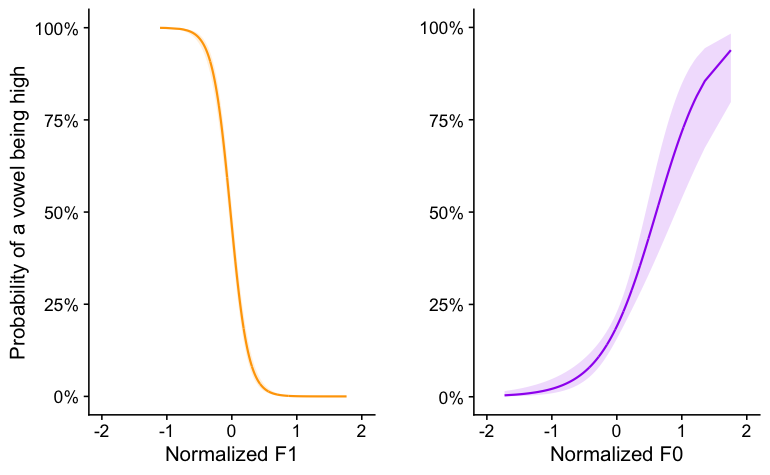

```r
# Plot for F1
plot_f1 <- plot_model(final_model, type = "pred", terms = "F1_Regression_Normalized [all]", mdrt.values = "meansd", color = "orange") +
  theme_cowplot() +
  xlim(c(-2,2))+
  labs(y = "Probability of a vowel being high", x = "Normalized F1") +
  theme(plot.title = element_blank(), plot.subtitle = element_blank(), plot.caption = element_blank())

# Plot for F0
plot_f0 <- plot_model(final_model, type = "pred", terms = "F0_Regression_Normalized [all]", mdrt.values = "meansd", color = "purple") +
  theme_cowplot() +
  xlim(c(-2,2))+
  labs(y = "", x = "Normalized F0") +
  theme(plot.title = element_blank(), plot.subtitle = element_blank(), plot.caption = element_blank())

# Combine plots
combined_plots <- grid.arrange(plot_f1, plot_f0, ncol = 2)
```

```r
# Print combined plot
print(combined_plots)
```

| z | cells | name | grob |
| --- | --- | --- | --- |
| 1 | (1-1,1-1) | arrange | gtable[layout] |
| 2 | (1-1,2-2) | arrange | gtable[layout] |

## 4.2. Consistency of F0 effect across vowel heights 📊

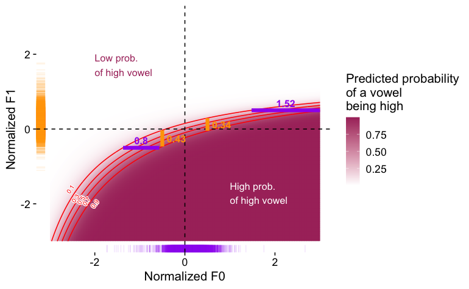

```r
new_data <- expand.grid(
  F0_Regression_Normalized = seq(-3,3, length.out = 1000),
  F1_Regression_Normalized = seq(-3,3, length.out = 1000),
  log_cum = mean(df$log_cum),
  frt = "bck"
)

# Predict using the model
new_data$predicted <- predict(final_model, newdata = new_data, re.form = NA, type = "response")

# Find the value of F1_Regression_Normalized closest to -1
closest_F1_to_minus_1 <- new_data$F1_Regression_Normalized[which.min(abs(new_data$F1_Regression_Normalized + 0.5))]

# Find the value of F1_Regression_Normalized closest to 0.5
closest_F1_to_0.5 <- new_data$F1_Regression_Normalized[which.min(abs(new_data$F1_Regression_Normalized - 0.5))]

# Find the value of F0_Regression_Normalized closest to 1
closest_F0_to_1 <- new_data$F0_Regression_Normalized[which.min(abs(new_data$F0_Regression_Normalized - 0.5))]

# Find the value of F0_Regression_Normalized closest to -1
closest_F0_to_minus_1 <- new_data$F0_Regression_Normalized[which.min(abs(new_data$F0_Regression_Normalized + 0.5))]


# Filter the data where predicted probability is between 0.2 and 0.8 for each closest value of F1_Regression_Normalized
filtered_data_minus_1 <- new_data[new_data$predicted > 0.2 & new_data$predicted < 0.8 & new_data$F1_Regression_Normalized == closest_F1_to_minus_1, ]
filtered_data_0.5 <- new_data[new_data$predicted > 0.2 & new_data$predicted < 0.8 & new_data$F1_Regression_Normalized == closest_F1_to_0.5, ]
filtered_data_1 <- new_data[new_data$predicted > 0.2 & new_data$predicted < 0.8 & new_data$F0_Regression_Normalized == closest_F0_to_1, ]
filtered_data_minus_1_F0 <- new_data[new_data$predicted > 0.2 & new_data$predicted < 0.8 & new_data$F0_Regression_Normalized == closest_F0_to_minus_1, ]

# Find the minimum and maximum values of F0_Regression_Normalized for each filtered data
min_x_minus_1 <- min(filtered_data_minus_1$F0_Regression_Normalized)
max_x_minus_1 <- max(filtered_data_minus_1$F0_Regression_Normalized)

min_x_0.5 <- min(filtered_data_0.5$F0_Regression_Normalized)
max_x_0.5 <- max(filtered_data_0.5$F0_Regression_Normalized)

min_x_1 <- min(filtered_data_1$F1_Regression_Normalized)
max_x_1 <- max(filtered_data_1$F1_Regression_Normalized)

min_x_minus_1_F0 <- min(filtered_data_minus_1_F0$F1_Regression_Normalized)
max_x_minus_1_F0 <- max(filtered_data_minus_1_F0$F1_Regression_Normalized)

ggplot() +
  geom_tile(data = new_data, aes(x = F0_Regression_Normalized, y = F1_Regression_Normalized,fill = predicted)) +   # Add tiled heatmap
  geom_contour(data = new_data,aes(x = F0_Regression_Normalized, y = F1_Regression_Normalized,z = predicted), breaks = seq(0, 1, by = 0.2), color = "red") +   # Add contour lines
  scale_fill_gradient(low = "white", high = "#AA336A") +   # Set color gradient
  labs(x = "Normalized F0", y = "Normalized F1", fill = "Predicted probability \nof a vowel \nbeing high") +   # Set axis and legend labels
  theme_cowplot() +   # Apply cowplot theme
  xlim(c(-3,3))+
  ylim(c(-3,3))+
  geom_rug(data = df, aes(x = F0_Regression_Normalized), color = "purple", alpha = 0.1) +
  geom_rug(data = df, aes(y = F1_Regression_Normalized), color = "orange", alpha = 0.1) +
  geom_vline(xintercept = 0, linetype = "dashed", color = "black") +   # Add vertical line at x = 0
  geom_hline(yintercept = 0, linetype = "dashed", color = "black") +   # Add horizontal line at y = 0
  theme(axis.line = element_blank()) +
  annotate("text", x = 1, y = -2, label = "High prob. \nof high vowel", hjust = 0, vjust = 0, color ="white") +   # Add annotation for high vowel quadrant
  annotate("text", x = -2, y = 2, label = "Low prob. \nof high vowel", hjust = 0, vjust = 1, color = "#AA336A")+
  metR::geom_text_contour(data = new_data, aes(x = F0_Regression_Normalized, y = F1_Regression_Normalized,z = predicted),label.placer = label_placer_fraction(0.15), color = "red", stroke = 0.15, size=2.5) +
  geom_segment(aes(x = min_x_minus_1, xend = max_x_minus_1, y = closest_F1_to_minus_1, yend = closest_F1_to_minus_1), color = "purple", size = 2) +
  annotate("text", x = (min_x_minus_1 + max_x_minus_1) / 2, y = closest_F1_to_minus_1 + 0.1,
             label = paste(round(max_x_minus_1 - min_x_minus_1, 2)),
             hjust = 0.5, vjust = 0, color = "purple", fontface = "bold") +
  geom_segment(aes(x = min_x_0.5, xend = max_x_0.5, y = closest_F1_to_0.5, yend = closest_F1_to_0.5), color = "purple", size = 2) +
  annotate("text", x = (min_x_0.5 + max_x_0.5) / 2, y = closest_F1_to_0.5 + 0.1,
             label = paste(round(max_x_0.5 - min_x_0.5, 2)),
             hjust = 0.5, vjust = 0, color = "purple", fontface = "bold") +
  geom_segment(aes(x = closest_F0_to_1, xend = closest_F0_to_1, y = min_x_1, yend = max_x_1), color = "orange", size = 2) +
  annotate("text", x = closest_F0_to_1 + 0.1, y = (min_x_1 + max_x_1) / 2,
             label = paste(round(max_x_1 - min_x_1, 2)),
             hjust = 0, vjust = 0.5, color = "orange", fontface = "bold") +
  geom_segment(aes(x = closest_F0_to_minus_1, xend = closest_F0_to_minus_1, y = min_x_minus_1_F0, yend = max_x_minus_1_F0), color = "orange", size = 2) +
  annotate("text", x = closest_F0_to_minus_1 + 0.1, y = (min_x_minus_1_F0 + max_x_minus_1_F0) / 2,
             label = paste(round(max_x_minus_1_F0 - min_x_minus_1_F0, 2)),
             hjust = 0, vjust = 0.5, color = "orange", fontface = "bold")
```

## 4.3. Developmental trajectories

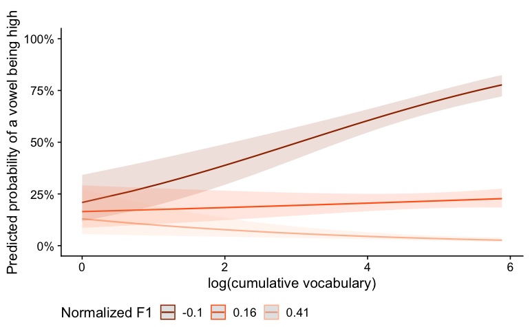

```r
# Define colors for F1 and F0
f1_color <- c("#9F3400","#FF681F","#FFBE9F")
f0_color <- c("#570987","#A020F0","#D397F8")

# Plot for F1
plot_f1 <- plot_model(final_model, type = "pred", terms = c("log_cum [all]", "F1_Regression_Normalized")) +
  labs(color = "Normalized F1", y = "Predicted probability of a vowel being high", x = "log(cumulative vocabulary)", title = "") +
  theme_cowplot() +
  scale_color_manual(values = f1_color) +  # Specify color for F1
  scale_fill_manual(values = f1_color) +  # Specify color for F1
  scale_y_continuous(labels = percent_format(), limits = c(0, 1)) +    # Set y-axis limits from 0 to 1
  theme(legend.position = "bottom", legend.box = "horizontal")  # Legend at the bottom in horizontal orientation
# Plot for F0
plot_f0 <- plot_model(final_model, type = "pred", terms = c("log_cum [all]", "F0_Regression_Normalized")) +
  labs(color = "Normalized F0", y = "Predicted probability of a vowel being high", x = "log(cumulative vocabulary)", title = "") +
  theme_cowplot() +
  scale_color_manual(values = f0_color) +  # Specify color for F0
  scale_fill_manual(values = f0_color) +  # Specify color for F0
   scale_y_continuous(labels = percent_format(), limits = c(0, 1)) +    # Set y-axis limits from 0 to 1
  theme(legend.position = "bottom", legend.box = "horizontal")  # Legend at the bottom in horizontal orientation
# Legend at the bottom in horizontal orientation

# Adjust plot width and height
plot_f1
```

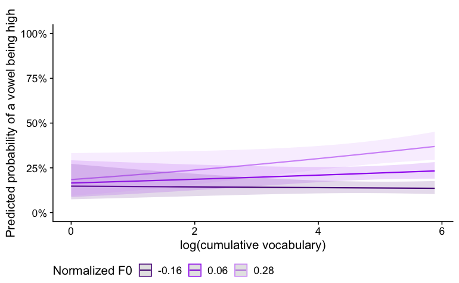

```r
plot_f0
```

```r
df_plot_f1 <- plot_f1$data
df_plot_f0 <- plot_f0$data

print(as.data.frame(df_plot_f0))
```

|  | x | predicted | std.error | conf.low | conf.high | group | group_col |
| --- | --- | --- | --- | --- | --- | --- | --- |
| 1 | 0.000 | 0.1477012 | 0.3928906 | 0.07427539 | 0.2723575 | -0.16 | -0.16 |
| 2 | 0.000 | 0.1652853 | 0.3750906 | 0.08670233 | 0.2922972 | 0.06 | 0.06 |
| 3 | 0.000 | 0.1845096 | 0.4021944 | 0.09326756 | 0.3322998 | 0.28 | 0.28 |
| 4 | 0.693 | 0.1462596 | 0.3442228 | 0.08025347 | 0.2516974 | -0.16 | -0.16 |
| 5 | 0.693 | 0.1723411 | 0.3274295 | 0.09877809 | 0.2834574 | 0.06 | 0.06 |
| 6 | 0.693 | 0.2019732 | 0.3525504 | 0.11254612 | 0.3355873 | 0.28 | 0.28 |
| 7 | 1.099 | 0.1454205 | 0.3162759 | 0.08387159 | 0.2402899 | -0.16 | -0.16 |
| 8 | 1.099 | 0.1765844 | 0.2999127 | 0.10645446 | 0.2785141 | 0.06 | 0.06 |
| 9 | 1.099 | 0.2127641 | 0.3241328 | 0.12524933 | 0.3378131 | 0.28 | 0.28 |
| 10 | 1.386 | 0.1448297 | 0.2968538 | 0.08646637 | 0.2325587 | -0.16 | -0.16 |

[output cut: 440 more lines]

```r
print(as.data.frame(df_plot_f1))
```

|  | x | predicted | std.error | conf.low | conf.high | group | group_col |
| --- | --- | --- | --- | --- | --- | --- | --- |
| 1 | 0.000 | 0.20878044 | 0.3454858 | 0.11821616 | 0.34182937 | -0.1 | -0.1 |
| 2 | 0.000 | 0.16466349 | 0.3756767 | 0.08625500 | 0.29160166 | 0.16 | 0.16 |
| 3 | 0.000 | 0.12961668 | 0.4741008 | 0.05553670 | 0.27385883 | 0.41 | 0.41 |
| 4 | 0.693 | 0.26343905 | 0.2985242 | 0.16613556 | 0.39100893 | -0.1 | -0.1 |
| 5 | 0.693 | 0.17124621 | 0.3279739 | 0.09800081 | 0.28211317 | 0.16 | 0.16 |
| 6 | 0.693 | 0.10867285 | 0.4175354 | 0.05104160 | 0.21652805 | 0.41 | 0.41 |
| 7 | 1.099 | 0.29943343 | 0.2715642 | 0.20064733 | 0.42122635 | -0.1 | -0.1 |
| 8 | 1.099 | 0.17519881 | 0.3004335 | 0.10545228 | 0.27680169 | 0.16 | 0.16 |
| 9 | 1.099 | 0.09783179 | 0.3851669 | 0.04850052 | 0.18745414 | 0.41 | 0.41 |
| 10 | 1.386 | 0.32650229 | 0.2528428 | 0.22800502 | 0.44312600 | -0.1 | -0.1 |

[output cut: 440 more lines]

## 4.4. Effect of log_cum - When does it appear?

```r
pr_F1<-predict_response(final_model,c("F1_Regression_Normalized", "log_cum" ))
```

```
Data were 'prettified'. Consider using `terms="F1_Regression_Normalized [all]"` to get smooth
  plots.
```

```
The association between `F1_Regression_Normalized` and `hgt` is negative for values of
  `log_cum` higher than 0.32. There were no clear associations for values of `log_cum` lower
  than 0.32.
```

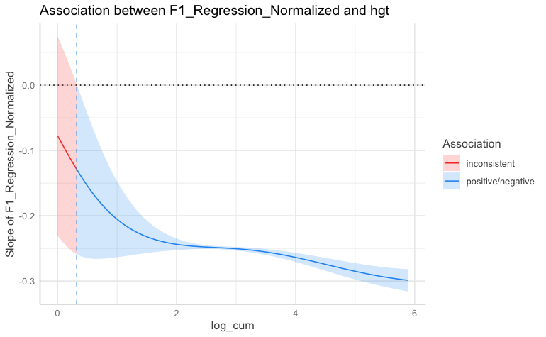

```r
jn_pr_F1 <- plot(johnson_neyman(pr_F1))  +
    scale_color_manual(values = c("inconsistent" = "grey", "positive/negative" = "orange")) +
  scale_fill_manual(values = c("inconsistent" = "grey", "positive/negative" = "orange")) +
  labs(y = "Slope of Normalized F1", x = "log(cumulative vocabulary)", title = "") +
  theme_cowplot() +
  theme(legend.position = "bottom", legend.box = "horizontal")
```

```r
pr_F0<-predict_response(final_model,c("F0_Regression_Normalized", "log_cum"))
```

```
Data were 'prettified'. Consider using `terms="F0_Regression_Normalized [all]"` to get smooth
  plots.
```

```
The association between `F0_Regression_Normalized` and `hgt` is positive for values of
  `log_cum` higher than 0.85. There were no clear associations for values of `log_cum` lower
  than 0.85.
```

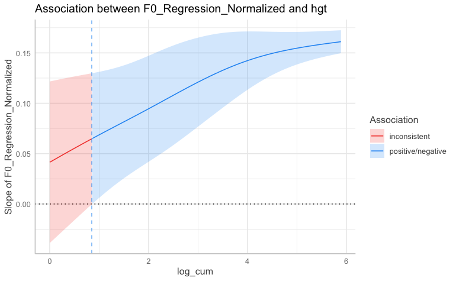

```r
jn_pr_F0 <- plot(johnson_neyman(pr_F0))  +
  scale_color_manual(values = c("inconsistent" = "grey", "positive/negative" = "purple")) +
  scale_fill_manual(values = c("inconsistent" = "grey", "positive/negative" = "purple")) +
  labs(y = "Slope of Normalized F0", x = "log(cumulative vocabulary)", title = "") +
  theme_cowplot() +
  theme(legend.position = "bottom",
        legend.box = "horizontal")
```

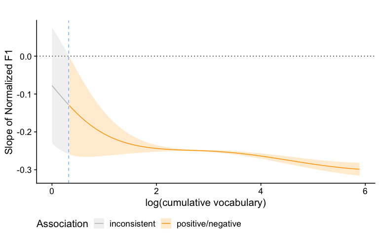

```r
jn_pr_F1
```

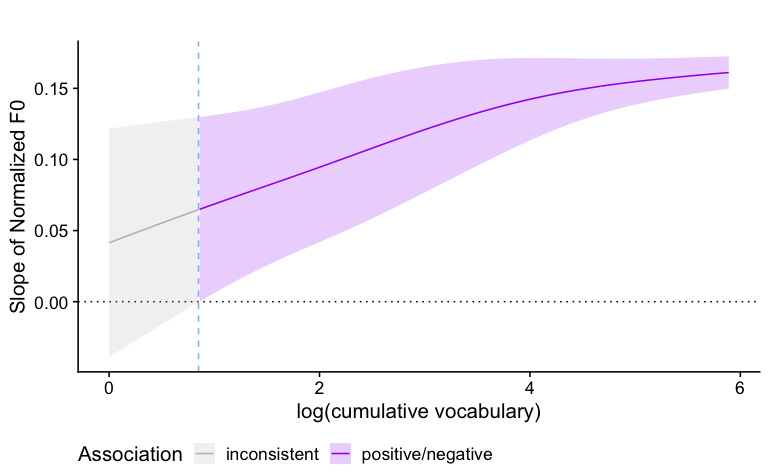

```r
jn_pr_F0
```

## 4.4. Between children variability

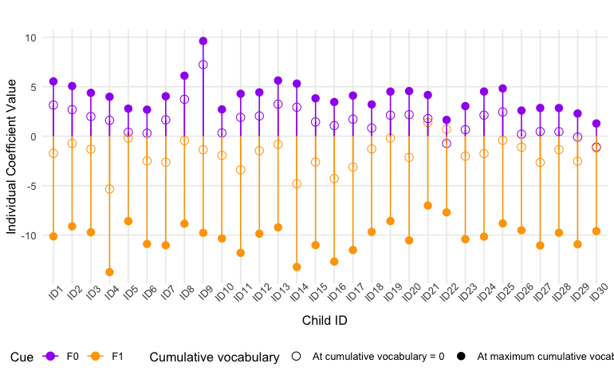

```r
# Extract coefficient values and convert to a data frame
coefficients_0<- as.data.frame(coef(final_model)$CHILD)
coefficients_0$id <- row.names(coefficients_0)   # Add ID as a column
coefficients_0$id <- as.factor(coefficients_0$id)   # Convert ID to factor

# Reshape the data frame from wide to long format
coefficients_0<- pivot_longer(coefficients_0, cols = c(F0_Regression_Normalized, F1_Regression_Normalized), names_to = "Variable", values_to = "Value")

# Extract coefficient values and convert to a data frame
coefficients_max<- as.data.frame(coef(refit_model_max)$CHILD)
coefficients_max$id <- row.names(coefficients_max)   # Add ID as a column
coefficients_max$id <- as.factor(coefficients_max$id)   # Convert ID to factor


# Reshape the data frame from wide to long format
coefficients_max<- pivot_longer(coefficients_max, cols = c(F0_Regression_Normalized, F1_Regression_Normalized), names_to = "Variable", values_to = "Value")

# Add a "Centering" column to identify where the coefficients come from
coefficients_0$Centering <- "Centered_at_0"
coefficients_max$Centering <- "Centered_at_Max"


# Combine the two data frames
coef_full <- bind_rows(coefficients_0, coefficients_max)

# Add a new column to control alpha
coef_full$Alpha <- ifelse(coef_full$Centering == "Centered_at_0", 0.9, 1)  # Circles = 0.3, Triangles = 1

# Update the levels and labels for better readability
coef_full$Variable <- factor(coef_full$Variable,
                             levels = c("F0_Regression_Normalized", "F1_Regression_Normalized"),
                             labels = c("F0", "F1"))

coef_full$Centering <- factor(coef_full$Centering,
                              levels = c("Centered_at_0", "Centered_at_Max"),
                              labels = c("At cumulative vocabulary = 0", "At maximum cumulative vocabulary"))

# Lollipop plot: Compare coefficients across Centered at 0 and Centered at Max
ggplot(coef_full, aes(x = id, y = Value)) +
  geom_point(size = 3, aes(color = Variable, shape = Centering)) +  # Add points
  scale_shape_manual(values = c("At cumulative vocabulary = 0" = 1, "At maximum cumulative vocabulary" = 16)) +
  scale_color_manual(values = c("F0" = "purple", "F1" = "orange")) +
  geom_segment(aes(x = id, xend = id, y = 0, yend = Value, color = Variable), size = 0.5) +  # Lollipop lines
  labs(
    title = "",
    x = "Child ID",
    y = "Individual Coefficient Value",
    color = "Cue",
    shape = "Cumulative vocabulary"
  ) +
  scale_x_discrete(labels = paste("ID", seq_along(unique(coef_full$id)), sep = "")) +
  theme_minimal() +
  theme(
    legend.position = "bottom",         # Move legend to the bottom
    legend.direction = "horizontal",    # Arrange legend items horizontally
    legend.box = "horizontal",          # Ensure alignment
    axis.text.x = element_text(angle = 45, hjust = 0.5),  # Set x-axis text to horizontal (0 degrees)
    plot.title = element_text(size = 16, hjust = 0.5),   # Center title
   # panel.grid.major.y = element_blank(),   # Remove the major horizontal gridlines
    panel.grid.minor.y = element_blank()    # Optionally remove minor horizontal gridlines as well
  )
```

```r
NA
NA
```

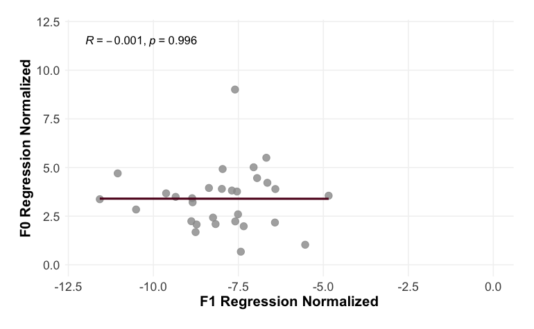

```r
# Extract coefficient values and convert to a data frame for final_model
coefficients_final <- as.data.frame(coef(final_model)$CHILD)
coefficients_final$id <- row.names(coefficients_final)
coefficients_final$model <- "final"

# Same for refit_model_max
coefficients_refit <- as.data.frame(coef(refit_model_max)$CHILD)
coefficients_refit$id <- row.names(coefficients_refit)
coefficients_refit$model <- "refit"

# Extract coefficient values and convert to a data frame for mean-centered model
coefficients_mean <- as.data.frame(coef(refit_model_ctr_mean )$CHILD)
coefficients_mean$id <- row.names(coefficients_mean)
coefficients_mean$model <- "mean_centered"

# Combine final, refit, and mean-centered coefficients into one data frame
coefficients_combined <- rbind(coefficients_final, coefficients_refit, coefficients_mean)

# Make sure id is a factor
coefficients_combined$id <- as.factor(coefficients_combined$id)

# Gather F1 and F0 into one 'variable' column
coefficients_long <- coefficients_combined %>%
  select(id, model, F1_Regression_Normalized, F0_Regression_Normalized) %>%
  gather(key = "variable", value = "value", F1_Regression_Normalized, F0_Regression_Normalized)

# Spread by model (final, refit, and mean-centered)
coefficients_wide <- coefficients_long %>%
  spread(key = model, value = value)

# Pivot wider to include final, refit, and mean-centered values
coefficients_final_wide <- coefficients_wide %>%
  pivot_wider(
    names_from = variable,
    values_from = c(final, refit, mean_centered)
  )

ggplot(coefficients_final_wide, aes(x = mean_centered_F1_Regression_Normalized,
                                    y = mean_centered_F0_Regression_Normalized)) +
  geom_point(color = "grey60", size = 3, alpha = 0.8) +
  sm_statCorr(color = "#5F021F")+
  xlim(-12,0)+
  ylim(0,12)+
  theme_minimal() +
  theme(
    legend.position = "bottom",
    legend.direction = "horizontal",
    legend.box = "horizontal",
    panel.grid.major = element_line(color = "gray95", size = 0.5),  # Subtle grid lines
    panel.grid.minor = element_blank(),  # Remove minor grid lines for a cleaner look
    axis.title = element_text(size = 14, face = "bold"),
    axis.text = element_text(size = 12),
    plot.title = element_text(size = 16, face = "bold", hjust = 0.5),
    plot.margin = margin(20, 20, 20, 20)  # Add margin for aesthetics
  ) +
  labs(
    x = "F1 Regression Normalized",
    y = "F0 Regression Normalized")
```

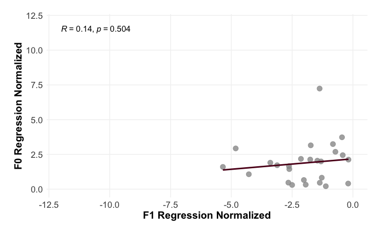

```r
ggplot(coefficients_final_wide, aes(x = final_F1_Regression_Normalized,
                                    y = final_F0_Regression_Normalized)) +
  geom_point(color = "grey60", size = 3, alpha = 0.8) +
  sm_statCorr(color = "#5F021F")+
  xlim(-12,0)+
  ylim(0,12)+
  theme_minimal() +
  theme(
    legend.position = "bottom",
    legend.direction = "horizontal",
    legend.box = "horizontal",
    panel.grid.major = element_line(color = "gray95", size = 0.5),  # Subtle grid lines
    panel.grid.minor = element_blank(),  # Remove minor grid lines for a cleaner look
    axis.title = element_text(size = 14, face = "bold"),
    axis.text = element_text(size = 12),
    plot.title = element_text(size = 16, face = "bold", hjust = 0.5),
    plot.margin = margin(20, 20, 20, 20)  # Add margin for aesthetics
  ) +
  labs(
    x = "F1 Regression Normalized",
    y = "F0 Regression Normalized")
```

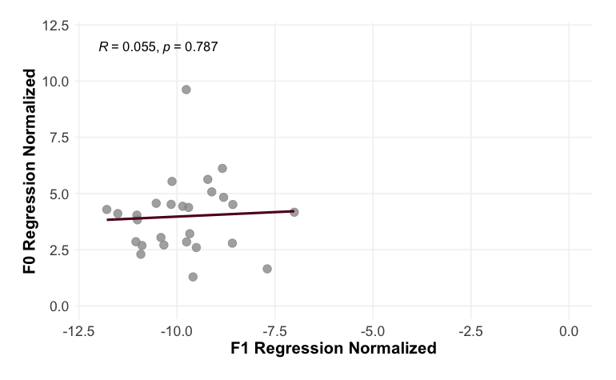

```r
ggplot(coefficients_final_wide, aes(x = refit_F1_Regression_Normalized,
                                    y = refit_F0_Regression_Normalized)) +
  geom_point(color = "grey60", size = 3, alpha = 0.8) +
  sm_statCorr(color = "#5F021F")+
  xlim(-12,0)+
  ylim(0,12)+
  theme_minimal() +
  theme(
    legend.position = "bottom",
    legend.direction = "horizontal",
    legend.box = "horizontal",
    panel.grid.major = element_line(color = "gray95", size = 0.5),  # Subtle grid lines
    panel.grid.minor = element_blank(),  # Remove minor grid lines for a cleaner look
    axis.title = element_text(size = 14, face = "bold"),
    axis.text = element_text(size = 12),
    plot.title = element_text(size = 16, face = "bold", hjust = 0.5),
    plot.margin = margin(20, 20, 20, 20)  # Add margin for aesthetics
  ) +
  labs(
    x = "F1 Regression Normalized",
    y = "F0 Regression Normalized")
```

```r
NA
NA
NA
NA
```

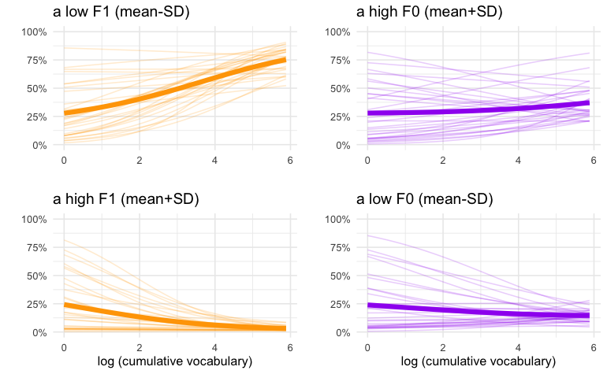

```r
# Choose constant values for F1_Regression_Normalized and F0_Regression_Normalized
constant_F1_low <- mean(df$F1_Regression_Normalized) - 1*sd(df$F1_Regression_Normalized)
constant_F0_high <- mean(df$F0_Regression_Normalized) + 1*sd(df$F0_Regression_Normalized)
constant_F1_high <- mean(df$F1_Regression_Normalized) + 1*sd(df$F1_Regression_Normalized)
constant_F0_low <- mean(df$F0_Regression_Normalized) - 1*sd(df$F0_Regression_Normalized)

# Define a sequence of values for log_cum
log_cum_seq <- seq(from = min(df$log_cum), to = max(df$log_cum), length.out = 100)

# Create new data for both scenarios
new_data_low_F1 <- data.frame(
  F1_Regression_Normalized = constant_F1_low,
  F0_Regression_Normalized = mean(df$F0_Regression_Normalized, na.rm=T),
  log_cum = log_cum_seq,
  frt = "bck",
  CHILD = rep(unique(df$CHILD), each = length(log_cum_seq))
)

new_data_high_F0 <- data.frame(
  F0_Regression_Normalized = constant_F0_high,
  F1_Regression_Normalized = mean(df$F1_Regression_Normalized, na.rm=T),
  log_cum = log_cum_seq,
    frt = "bck",
  CHILD = rep(unique(df$CHILD), each = length(log_cum_seq))
)

new_data_high_F1 <- data.frame(
  F1_Regression_Normalized = constant_F1_high,
  F0_Regression_Normalized = mean(df$F0_Regression_Normalized, na.rm=T),
  log_cum = log_cum_seq,
    frt = "bck",
  CHILD = rep(unique(df$CHILD), each = length(log_cum_seq))
)

new_data_low_F0 <- data.frame(
  F0_Regression_Normalized = constant_F0_low,
  F1_Regression_Normalized = mean(df$F1_Regression_Normalized, na.rm=T),
  log_cum = log_cum_seq,
    frt = "bck",
  CHILD = rep(unique(df$CHILD), each = length(log_cum_seq))
)

# Predict probabilities for the new data
predicted_probs_low_F1 <- predict(final_model, newdata = new_data_low_F1, type = "response")
predicted_probs_high_F0 <- predict(final_model, newdata = new_data_high_F0, type = "response")
predicted_probs_high_F1 <- predict(final_model, newdata = new_data_high_F1, type = "response")
predicted_probs_low_F0 <- predict(final_model, newdata = new_data_low_F0, type = "response")

# Combine log_cum_seq, predicted_probs, and CHILD into data frames
predicted_df_low_F1 <- data.frame(
  log_cum = rep(log_cum_seq, length(unique(df$CHILD))),
  predicted_prob = predicted_probs_low_F1,
  CHILD = rep(unique(df$CHILD), each = length(log_cum_seq))
)

predicted_df_high_F0 <- data.frame(
  log_cum = rep(log_cum_seq, length(unique(df$CHILD))),
  predicted_prob = predicted_probs_high_F0,
  CHILD = rep(unique(df$CHILD), each = length(log_cum_seq))
)

predicted_df_high_F1 <- data.frame(
  log_cum = rep(log_cum_seq, length(unique(df$CHILD))),
  predicted_prob = predicted_probs_high_F1,
  CHILD = rep(unique(df$CHILD), each = length(log_cum_seq))
)

predicted_df_low_F0 <- data.frame(
  log_cum = rep(log_cum_seq, length(unique(df$CHILD))),
  predicted_prob = predicted_probs_low_F0,
  CHILD = rep(unique(df$CHILD), each = length(log_cum_seq))
)

# Calculate average predicted probabilities
average_prob_low_F1 <- predicted_df_low_F1 %>%
  group_by(log_cum) %>%
  summarize(average_prob = mean(predicted_prob))

average_prob_high_F0 <- predicted_df_high_F0 %>%
  group_by(log_cum) %>%
  summarize(average_prob = mean(predicted_prob))

average_prob_high_F1 <- predicted_df_high_F1 %>%
  group_by(log_cum) %>%
  summarize(average_prob = mean(predicted_prob))

average_prob_low_F0 <- predicted_df_low_F0 %>%
  group_by(log_cum) %>%
  summarize(average_prob = mean(predicted_prob))

# Plot the lines
plot1 <- ggplot(predicted_df_low_F1) +
  geom_line(aes(x = log_cum, y = predicted_prob, group = CHILD), color = "orange", alpha = 0.2) +
  geom_line(data = average_prob_low_F1, aes(x = log_cum, y = average_prob), color = "orange", size = 2) +
  labs(x = "", y = "", title = "a low F1 (mean-SD)") +
     scale_y_continuous(labels = percent_format(), limits = c(0, 1)) +
  theme_minimal()

plot2 <- ggplot(predicted_df_high_F0) +
  geom_line(aes(x = log_cum, y = predicted_prob, group = CHILD), color = "purple", alpha = 0.2) +
  geom_line(data = average_prob_high_F0, aes(x = log_cum, y = average_prob), color = "purple", size = 2) +
  labs(x = "", y = "", title = "a high F0 (mean+SD)") +
     scale_y_continuous(labels = percent_format(), limits = c(0, 1)) +
  theme_minimal()

plot3 <- ggplot(predicted_df_high_F1) +
  geom_line(aes(x = log_cum, y = predicted_prob, group = CHILD), color = "orange", alpha = 0.2) +
  geom_line(data = average_prob_high_F1, aes(x = log_cum, y = average_prob), color = "orange", size = 2) +
  labs(x = "log (cumulative vocabulary)", y = "", title = "a high F1 (mean+SD)") +
     scale_y_continuous(labels = percent_format(), limits = c(0, 1)) +
  theme_minimal()

plot4 <- ggplot(predicted_df_low_F0) +
  geom_line(aes(x = log_cum, y = predicted_prob, group = CHILD), color = "purple", alpha = 0.2) +
  geom_line(data = average_prob_low_F0, aes(x = log_cum, y = average_prob), color = "purple", size = 2) +
  labs(x = "log (cumulative vocabulary)", y = "", title = "a low F0 (mean-SD)") +
     scale_y_continuous(labels = percent_format(), limits = c(0, 1)) +
  theme_minimal()

# Combine plots
combined_plots <- grid.arrange(plot1, plot2, plot3, plot4, ncol = 2)
```

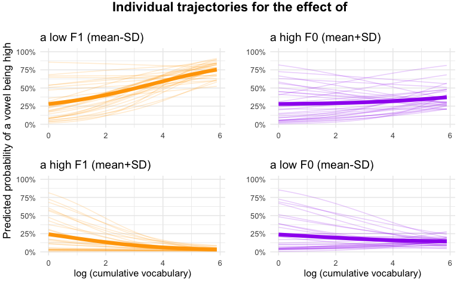

```r
# Add overall title
overall_title <- ggdraw() +
  draw_label("Individual trajectories for the effect of", size = 15, fontface = "bold", x = 0.5)

# Add single y-axis label
y_label <- ggdraw() +
  draw_label("Predicted probability of a vowel being high", size = 12, angle = 90,
             x = 0.015, y = -1, vjust = 0.5, hjust = 1)
# Print combined plot with overall title
grid.arrange(overall_title, y_label, combined_plots, ncol = 1, heights = c(0.05, 0.05, 0.9))
```